# Iris_Data_Analysis_Notebook

```python
import pandas as pd
import numpy as np
```

```python
# Reading data
iris_df = pd.read_csv("iris.data", header = None)
```

```python
iris_df.head()
```

|  | 0 | 1 | 2 | 3 | 4 |
| --- | --- | --- | --- | --- | --- |
| 0 | 5.1 | 3.5 | 1.4 | 0.2 | Iris-setosa |
| 1 | 4.9 | 3.0 | 1.4 | 0.2 | Iris-setosa |
| 2 | 4.7 | 3.2 | 1.3 | 0.2 | Iris-setosa |
| 3 | 4.6 | 3.1 | 1.5 | 0.2 | Iris-setosa |
| 4 | 5.0 | 3.6 | 1.4 | 0.2 | Iris-setosa |

```python
# Since no column names given in dataset providing column names
iris_df.columns = ['Sepal length in cm', 'Sepal width in cm', 'Petal length in cm', 'Petal width in cm', 'Class']
```

```python
iris_df.head()
```

|  | Sepal length in cm | Sepal width in cm | Petal length in cm | Petal width in cm | Class |
| --- | --- | --- | --- | --- | --- |
| 0 | 5.1 | 3.5 | 1.4 | 0.2 | Iris-setosa |
| 1 | 4.9 | 3.0 | 1.4 | 0.2 | Iris-setosa |
| 2 | 4.7 | 3.2 | 1.3 | 0.2 | Iris-setosa |
| 3 | 4.6 | 3.1 | 1.5 | 0.2 | Iris-setosa |
| 4 | 5.0 | 3.6 | 1.4 | 0.2 | Iris-setosa |

```python
print(iris_df.shape)
```

```
(150, 5)
```

```python
# 150 rows and 5 columns
```

```python
iris_df.info()
```

```
<class 'pandas.core.frame.DataFrame'>
RangeIndex: 150 entries, 0 to 149
Data columns (total 5 columns):
Sepal length in cm    150 non-null float64
Sepal width in cm     150 non-null float64
Petal length in cm    150 non-null float64
Petal width in cm     150 non-null float64
Class                 150 non-null object
dtypes: float64(4), object(1)
memory usage: 5.9+ KB
```

```python
# We can see there are 4 columns with the type of float64 and 1 with type object
# There are no missing values present here since 150 entries are present and 150 entries are present for each column
```

```python
boolean_series = iris_df.duplicated()
iris_df[boolean_series.apply(lambda x: x == True)]
```

|  | Sepal length in cm | Sepal width in cm | Petal length in cm | Petal width in cm | Class |
| --- | --- | --- | --- | --- | --- |
| 34 | 4.9 | 3.1 | 1.5 | 0.1 | Iris-setosa |
| 37 | 4.9 | 3.1 | 1.5 | 0.1 | Iris-setosa |
| 142 | 5.8 | 2.7 | 5.1 | 1.9 | Iris-virginica |

There are 3 duplicate records present

```python
# There were 2 duplicate records for class = Iris-setosa and 1 for Iris-virginica
```

```python
iris_df.drop_duplicates(keep='first').shape
```

```
(147, 5)
```

```python
# For object type we are using value counts
iris_df["Class"].value_counts()
```

```
Iris-virginica     50
Iris-versicolor    50
Iris-setosa        50
Name: Class, dtype: int64
```

```python
# Class variable has 3 classes - Iris-virginica, Iris-versicolor and Iris-setosa. Each of the classes have 50 rows
# Each class has 50 records each and we have only 150 data points with us so not removing duplicates
# as the number of records for the class Iris-setosa and Iris-virginica will get reduced by 2 and 1 respectively
```

```python
# Summary Statistics
iris_df.groupby(["Class"]).describe().transpose()
```

|  | Class | Iris-setosa | Iris-versicolor | Iris-virginica |
| --- | --- | --- | --- | --- |
| Sepal length in cm | count | 50.000000 | 50.000000 | 50.000000 |
|  | mean | 5.006000 | 5.936000 | 6.588000 |
|  | std | 0.352490 | 0.516171 | 0.635880 |
|  | min | 4.300000 | 4.900000 | 4.900000 |
|  | 25% | 4.800000 | 5.600000 | 6.225000 |
|  | 50% | 5.000000 | 5.900000 | 6.500000 |
|  | 75% | 5.200000 | 6.300000 | 6.900000 |
|  | max | 5.800000 | 7.000000 | 7.900000 |
| Sepal width in cm | count | 50.000000 | 50.000000 | 50.000000 |
|  | mean | 3.418000 | 2.770000 | 2.974000 |
|  | std | 0.381024 | 0.313798 | 0.322497 |
|  | min | 2.300000 | 2.000000 | 2.200000 |
|  | 25% | 3.125000 | 2.525000 | 2.800000 |
|  | 50% | 3.400000 | 2.800000 | 3.000000 |
|  | 75% | 3.675000 | 3.000000 | 3.175000 |
|  | max | 4.400000 | 3.400000 | 3.800000 |
| Petal length in cm | count | 50.000000 | 50.000000 | 50.000000 |
|  | mean | 1.464000 | 4.260000 | 5.552000 |
|  | std | 0.173511 | 0.469911 | 0.551895 |
|  | min | 1.000000 | 3.000000 | 4.500000 |
|  | 25% | 1.400000 | 4.000000 | 5.100000 |
|  | 50% | 1.500000 | 4.350000 | 5.550000 |
|  | 75% | 1.575000 | 4.600000 | 5.875000 |
|  | max | 1.900000 | 5.100000 | 6.900000 |
| Petal width in cm | count | 50.000000 | 50.000000 | 50.000000 |
|  | mean | 0.244000 | 1.326000 | 2.026000 |
|  | std | 0.107210 | 0.197753 | 0.274650 |
|  | min | 0.100000 | 1.000000 | 1.400000 |
|  | 25% | 0.200000 | 1.200000 | 1.800000 |
|  | 50% | 0.200000 | 1.300000 | 2.000000 |
|  | 75% | 0.300000 | 1.500000 | 2.300000 |
|  | max | 0.600000 | 1.800000 | 2.500000 |

```python
import scipy.stats
iris_df.groupby(["Class"]).agg(lambda x: scipy.stats.mode(x)[0][0])
```

| Class | Sepal length in cm | Sepal width in cm | Petal length in cm | Petal width in cm |
| --- | --- | --- | --- | --- |
| Iris-setosa | 5.0 | 3.4 | 1.5 | 0.2 |
| Iris-versicolor | 5.5 | 3.0 | 4.5 | 1.3 |
| Iris-virginica | 6.3 | 3.0 | 5.1 | 1.8 |

```python
iris_df.describe().transpose()
```

|  | count | mean | std | min | 25% | 50% | 75% | max |
| --- | --- | --- | --- | --- | --- | --- | --- | --- |
| Sepal length in cm | 150.0 | 5.843333 | 0.828066 | 4.3 | 5.1 | 5.80 | 6.4 | 7.9 |
| Sepal width in cm | 150.0 | 3.054000 | 0.433594 | 2.0 | 2.8 | 3.00 | 3.3 | 4.4 |
| Petal length in cm | 150.0 | 3.758667 | 1.764420 | 1.0 | 1.6 | 4.35 | 5.1 | 6.9 |
| Petal width in cm | 150.0 | 1.198667 | 0.763161 | 0.1 | 0.3 | 1.30 | 1.8 | 2.5 |

```python
import scipy.stats
iris_df.groupby(["Class"]).agg(lambda x: scipy.stats.mode(x)[0][0])
```

| Class | Sepal length in cm | Sepal width in cm | Petal length in cm | Petal width in cm |
| --- | --- | --- | --- | --- |
| Iris-setosa | 5.0 | 3.4 | 1.5 | 0.2 |
| Iris-versicolor | 5.5 | 3.0 | 4.5 | 1.3 |
| Iris-virginica | 6.3 | 3.0 | 5.1 | 1.8 |

```python
# Left skewed if mode>median>mean
# Right skewed if mean>median>mode
# Sepal length in cm is right skewed for Iris-versicolor and Iris-virginica
# Sepal width in cm is left skewed for Iris-versicolor
# Petal length in cm is left skewed for Iris-versicolor
# Petal length in cm is right skewed for Iris-virginica
# Petal width in cm is right skewed for Iris-virginica
```

```python
# In order to see statistics on non-numerical features,
# one has to explicitly indicate data types of interest in the include parameter.
iris_df.describe(include = ['object']) # Data type of object is  included
```

|  | Class |
| --- | --- |
| count | 150 |
| unique | 3 |
| top | Iris-virginica |
| freq | 50 |

```python
import seaborn as sns
```

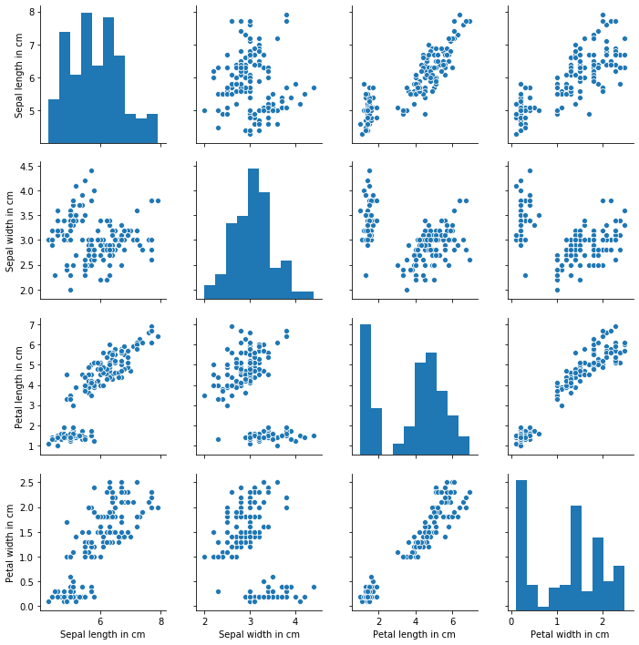

```python
sns.pairplot(iris_df)
```

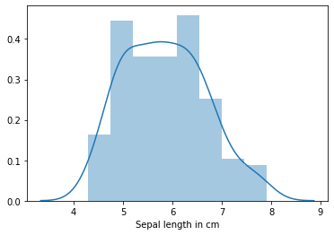

```python
sns.distplot(iris_df['Sepal length in cm'])
```

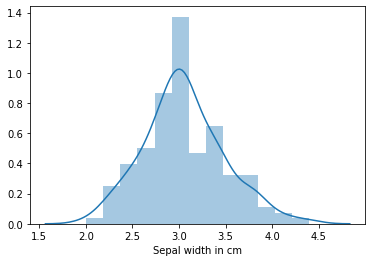

```python
sns.distplot(iris_df['Sepal width in cm'])
```

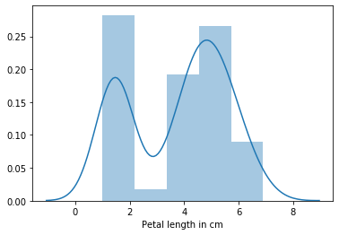

```python
sns.distplot(iris_df['Petal length in cm'])
```

Petal length in cm has 2 peaks so it looks to be bimodal distribution

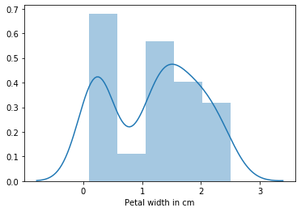

```python
sns.distplot(iris_df['Petal width in cm'])
```

Petal width in cm also has 2 peaks so it also looks to be bimodal distribution

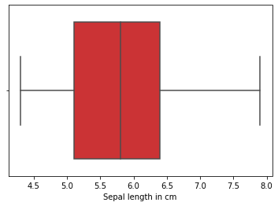

```python
sns.boxplot(x ='Sepal length in cm', data = iris_df, palette = "Set1")
```

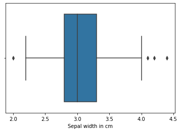

```python
sns.boxplot(x ='Sepal width in cm', data = iris_df)
```

```python
# There are outliers present in the data of "Sepal width in cm"
```

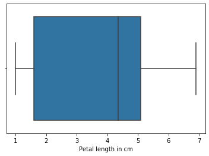

```python
sns.boxplot(x ='Petal length in cm', data = iris_df)
```

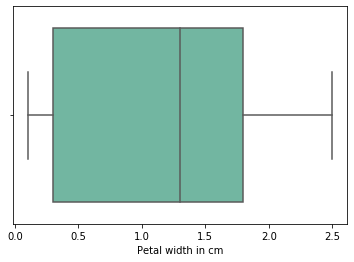

```python
sns.boxplot(x='Petal width in cm', data = iris_df, palette = "Set2")
```

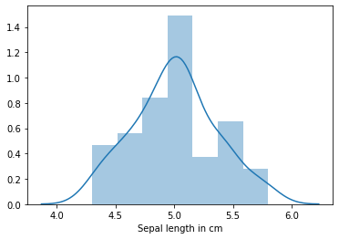

```python
sns.distplot(iris_df[iris_df["Class"]=='Iris-setosa']['Sepal length in cm'])
```

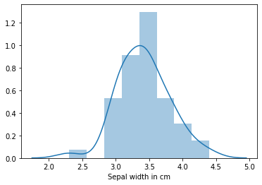

```python
sns.distplot(iris_df[iris_df["Class"]=='Iris-setosa']['Sepal width in cm'])
```

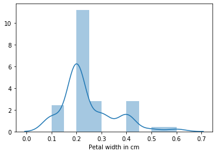

```python
sns.distplot(iris_df[iris_df["Class"]=='Iris-setosa']['Petal width in cm'])
```

Long tails can be seen

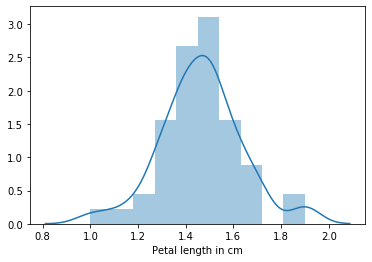

```python
sns.distplot(iris_df[iris_df["Class"]=='Iris-setosa']['Petal length in cm'])
```

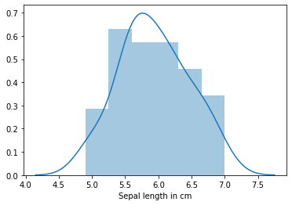

```python
sns.distplot(iris_df[iris_df["Class"]=='Iris-versicolor']['Sepal length in cm'])
```

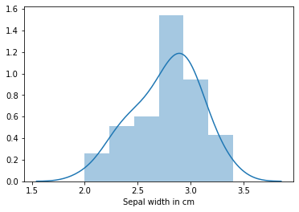

```python
sns.distplot(iris_df[iris_df["Class"]=='Iris-versicolor']['Sepal width in cm'])
```

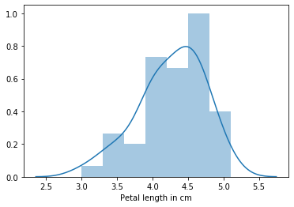

```python
sns.distplot(iris_df[iris_df["Class"]=='Iris-versicolor']['Petal length in cm'])
```

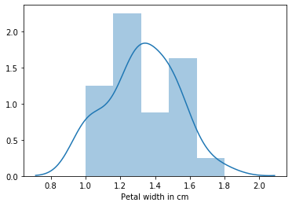

```python
sns.distplot(iris_df[iris_df["Class"]=='Iris-versicolor']['Petal width in cm'])
```

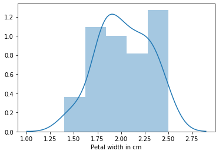

```python
sns.distplot(iris_df[iris_df["Class"]=='Iris-virginica']['Petal width in cm'])
```

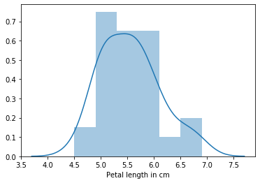

```python
sns.distplot(iris_df[iris_df["Class"]=='Iris-virginica']['Petal length in cm'])
```

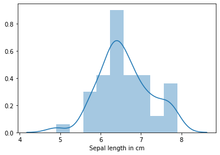

```python
sns.distplot(iris_df[iris_df["Class"]=='Iris-virginica']['Sepal length in cm'])
```

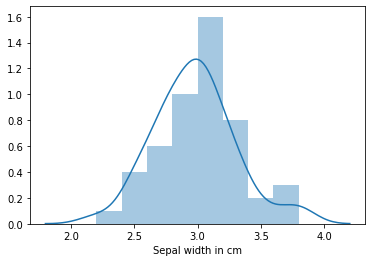

```python
sns.distplot(iris_df[iris_df["Class"]=='Iris-virginica']['Sepal width in cm'])
```

```python
iris_df.corr() # Correlation
```

|  | Sepal length in cm | Sepal width in cm | Petal length in cm | Petal width in cm |
| --- | --- | --- | --- | --- |
| Sepal length in cm | 1.000000 | -0.109369 | 0.871754 | 0.817954 |
| Sepal width in cm | -0.109369 | 1.000000 | -0.420516 | -0.356544 |
| Petal length in cm | 0.871754 | -0.420516 | 1.000000 | 0.962757 |
| Petal width in cm | 0.817954 | -0.356544 | 0.962757 | 1.000000 |

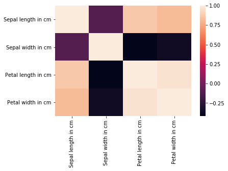

```python
sns.heatmap(iris_df.corr())
```

```python
# Sepal length in cm and Petal length in cm are positively correlated
# Sepal length in cm and Petal width in cm are positively correlated
# Petal length in cm and Petal width in cm are positively correlated
```

```python
# Classwise correlation
iris_df[iris_df['Class']=='Iris-virginica'].corr()
```

|  | Sepal length in cm | Sepal width in cm | Petal length in cm | Petal width in cm |
| --- | --- | --- | --- | --- |
| Sepal length in cm | 1.000000 | 0.457228 | 0.864225 | 0.281108 |
| Sepal width in cm | 0.457228 | 1.000000 | 0.401045 | 0.537728 |
| Petal length in cm | 0.864225 | 0.401045 | 1.000000 | 0.322108 |
| Petal width in cm | 0.281108 | 0.537728 | 0.322108 | 1.000000 |

```python
iris_df[iris_df['Class']=='Iris-versicolor'].corr()
```

|  | Sepal length in cm | Sepal width in cm | Petal length in cm | Petal width in cm |
| --- | --- | --- | --- | --- |
| Sepal length in cm | 1.000000 | 0.525911 | 0.754049 | 0.546461 |
| Sepal width in cm | 0.525911 | 1.000000 | 0.560522 | 0.663999 |
| Petal length in cm | 0.754049 | 0.560522 | 1.000000 | 0.786668 |
| Petal width in cm | 0.546461 | 0.663999 | 0.786668 | 1.000000 |

```python
iris_df[iris_df['Class']=='Iris-setosa'].corr()
```

|  | Sepal length in cm | Sepal width in cm | Petal length in cm | Petal width in cm |
| --- | --- | --- | --- | --- |
| Sepal length in cm | 1.000000 | 0.746780 | 0.263874 | 0.279092 |
| Sepal width in cm | 0.746780 | 1.000000 | 0.176695 | 0.279973 |
| Petal length in cm | 0.263874 | 0.176695 | 1.000000 | 0.306308 |
| Petal width in cm | 0.279092 | 0.279973 | 0.306308 | 1.000000 |

For class Iris-virginica, Iris-versicolor and Iris-setosa- it can be seen all are positively correlated. Points which can be noted apart from the points already mentioned before are - 1) For Iris-virginica and Iris-versicolor - 1) Sepal length in cm and Sepal width in cm are positively correlated 2) Sepal width in cm and Petal width in cm are positively correlated 3) Petal length in cm and Sepal width in cm are positively correlated 2) For Iris-versicolor alone - 1) Petal width in cm and Sepal length in cm are positively correlated 3) For Iris-setosa - 1) Sepal length in cm and Sepal width in cm are more positively correlated as compared to others 2) Petal length in cm and Petal width in cm are more positively correlated as compared to others

## Logistic Regression

```python
from sklearn.linear_model import LogisticRegression
from sklearn.model_selection import GridSearchCV
from sklearn.model_selection import train_test_split
from sklearn import metrics
```

```python
X = iris_df.drop('Class', axis=1)
Y = iris_df['Class']
X_train, X_test, y_train, y_test = train_test_split(X,Y, test_size = 0.3, random_state = 123)
```

```python
model = LogisticRegression()
```

```python
model.fit(X_train,y_train)
```

```
LogisticRegression(C=1.0, class_weight=None, dual=False, fit_intercept=True,
                   intercept_scaling=1, l1_ratio=None, max_iter=100,
                   multi_class='warn', n_jobs=None, penalty='l2',
                   random_state=None, solver='warn', tol=0.0001, verbose=0,
                   warm_start=False)
```

```python
y_predict = model.predict(X_test)
```

```python
model_score = model.score(X_test, y_test)
```

```python
print(model_score)
```

```
0.9777777777777777
```

```python
print(metrics.confusion_matrix(y_test,y_predict))
```

```
[[18  0  0]
 [ 0 10  0]
 [ 0  1 16]]
```

```python
# Since we have 3 classes, then your confusion matrix would be an 3×3 matrix,
# with the left axis showing the true class (as known in the test set) and the top axis showing
# the class assigned to an item with that true class. Each element i,j of the matrix would be the number of items
# with true class i that were classified as being in class j
```

```python
# Iris-setosa - 18 - correctly classified and 0 wrongly classified
# Iris-versicolor - 10 - correctly classified and 0 wrongly classified
# Iris-virginica - 16 correctly classified and 1 wrongly classified
```

```python
print(metrics.classification_report(y_test,y_predict))
```

```
                 precision    recall  f1-score   support

    Iris-setosa       1.00      1.00      1.00        18
Iris-versicolor       0.91      1.00      0.95        10
 Iris-virginica       1.00      0.94      0.97        17

       accuracy                           0.98        45
      macro avg       0.97      0.98      0.97        45
   weighted avg       0.98      0.98      0.98        45
```

```python
# Cross-validation
```

```python
from sklearn.model_selection import cross_val_score
```

```python
# Cross validation
cross_val_scores = cross_val_score(model, X_test, y_test, cv = 10)
```

[output not shown]

```python
print(cross_val_scores)
```

```
[0.8        0.8        1.         0.8        0.8        0.8
 1.         1.         0.66666667 1.        ]
```

```python
cross_val_scores.mean()
```

```
0.8666666666666668
```

```python
# Accuracy
metrics.accuracy_score(y_test,y_predict)
```

```
0.9777777777777777
```

## K Nearest Neighbours

```python
from sklearn.neighbors import KNeighborsClassifier
KNC = KNeighborsClassifier(n_neighbors=5, weights= 'distance')
```

```python
KNC.fit(X_train,y_train)
```

```
KNeighborsClassifier(algorithm='auto', leaf_size=30, metric='minkowski',
                     metric_params=None, n_jobs=None, n_neighbors=5, p=2,
                     weights='distance')
```

```python
predicted = KNC.predict(X_test)
```

```python
KNC_model_score = KNC.score(X_test,y_test)
```

```python
print(KNC_model_score)
```

```
0.9777777777777777
```

```python
print(metrics.confusion_matrix(y_test,predicted))
```

```
[[18  0  0]
 [ 0  9  1]
 [ 0  0 17]]
```

```python
# Iris-setosa - 18 - correctly classified and 0 wrongly classified
# Iris-versicolor - 9 correctly classified and 1 wrongly classified
# Iris-virginica - 17 correctly classified and 0 wrongly classified
```

```python
print(metrics.classification_report(y_test,predicted))
```

```
                 precision    recall  f1-score   support

    Iris-setosa       1.00      1.00      1.00        18
Iris-versicolor       1.00      0.90      0.95        10
 Iris-virginica       0.94      1.00      0.97        17

       accuracy                           0.98        45
      macro avg       0.98      0.97      0.97        45
   weighted avg       0.98      0.98      0.98        45
```

```python
# Accuracy
metrics.accuracy_score(y_test,predicted)
```

```
0.9777777777777777
```

```python
# Cross validation
cross_val_scores1 = cross_val_score(KNC, X_test, y_test, cv = 10)
```

```python
print(cross_val_scores1)
```

```
[0.8 1.  1.  1.  1.  0.8 0.8 1.  1.  1. ]
```

```python
cross_val_scores1.mean()
```

```
0.9400000000000001
```

## Naive Baiyes

```python
from sklearn.naive_bayes import GaussianNB
gnb_model = GaussianNB()
```

```python
gnb_model.fit(X_train,y_train)
```

```
GaussianNB(priors=None, var_smoothing=1e-09)
```

```python
gnb_predict = gnb_model.predict(X_test)
```

```python
gnb_model_score = gnb_model.score(X_test,y_test)
```

```python
print(gnb_model_score)
```

```
0.9555555555555556
```

```python
print(metrics.confusion_matrix(y_test,gnb_predict))
```

```
[[18  0  0]
 [ 0 10  0]
 [ 0  2 15]]
```

```python
# Iris-setosa - 18 - correctly classified - 0 - wrongly classified
# Iris-versicolor - 10 - correctly classified - 0 - wrongly classified
# Iris-virginica - 15 - correctly classified - 2 - wrongly classified
```

```python
# Accuracy
metrics.accuracy_score(y_test,gnb_predict)
```

```
0.9555555555555556
```

```python
print(metrics.classification_report(y_test,gnb_predict))
```

```
                 precision    recall  f1-score   support

    Iris-setosa       1.00      1.00      1.00        18
Iris-versicolor       0.83      1.00      0.91        10
 Iris-virginica       1.00      0.88      0.94        17

       accuracy                           0.96        45
      macro avg       0.94      0.96      0.95        45
   weighted avg       0.96      0.96      0.96        45
```

```python
# Cross validation
gnb_model_score = cross_val_score(gnb_model,X_test, y_test, cv = 10)
```

```python
print(gnb_model_score)
```

```
[0.8 1.  1.  1.  1.  1.  0.8 1.  1.  1. ]
```

```python
gnb_model_score.mean()
```

```
0.96
```

## Decision Tree

```python
from sklearn.tree import DecisionTreeClassifier
```

```python
# Using gini criterion
```

```python
dtc_model = DecisionTreeClassifier()
```

```python
dtc_model.fit(X_train,y_train)
```

```
DecisionTreeClassifier(class_weight=None, criterion='gini', max_depth=None,
                       max_features=None, max_leaf_nodes=None,
                       min_impurity_decrease=0.0, min_impurity_split=None,
                       min_samples_leaf=1, min_samples_split=2,
                       min_weight_fraction_leaf=0.0, presort=False,
                       random_state=None, splitter='best')
```

```python
dtc_predict= dtc_model.predict(X_test)
```

```python
from IPython.display import Image
from sklearn.tree import export_graphviz
import pydotplus
from sklearn.externals.six import StringIO

dot_data_dtc = StringIO()
export_graphviz(dtc_model, out_file = dot_data_dtc, filled = True, rounded = True, special_characters = True )
```

```python
dtc_graph = pydotplus.graph_from_dot_data(dot_data_dtc.getvalue())
```

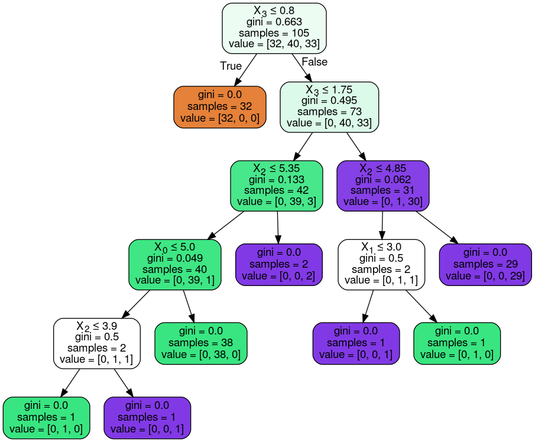

```python
Image(dtc_graph.create_png())
```

```python
dtc_score = dtc_model.score(X_test, y_test)
```

```python
print(dtc_score)
```

```
0.9555555555555556
```

```python
print(metrics.classification_report(y_test, dtc_predict))
```

```
                 precision    recall  f1-score   support

    Iris-setosa       1.00      1.00      1.00        18
Iris-versicolor       0.83      1.00      0.91        10
 Iris-virginica       1.00      0.88      0.94        17

       accuracy                           0.96        45
      macro avg       0.94      0.96      0.95        45
   weighted avg       0.96      0.96      0.96        45
```

```python
print(metrics.confusion_matrix(y_test, dtc_predict))
```

```
[[18  0  0]
 [ 0 10  0]
 [ 0  2 15]]
```

```python
# Iris-setosa - 18 - correctly classified - 0 - wrongly classified
# Iris-versicolor - 10 - correctly classified - 0 - wrongly classified
# Iris-virginica - 15 - correctly classified - 2 - wrongly classified
```

```python
# Accuracy
metrics.accuracy_score(y_test, dtc_predict)
```

```
0.9555555555555556
```

```python
# Cross validation
cross_val_scores2 = cross_val_score(dtc_model, X_test, y_test, cv = 10)
```

```python
print(cross_val_scores2)
```

```
[0.8 1.  1.  1.  1.  0.8 0.8 1.  1.  1. ]
```

```python
cross_val_scores2.mean()
```

```
0.9400000000000001
```

```python
# Now using entropy criterion
```

```python
dtc_model1 = DecisionTreeClassifier(criterion='entropy')
```

```python
dtc_model1.fit(X_train,y_train)
```

```
DecisionTreeClassifier(class_weight=None, criterion='entropy', max_depth=None,
                       max_features=None, max_leaf_nodes=None,
                       min_impurity_decrease=0.0, min_impurity_split=None,
                       min_samples_leaf=1, min_samples_split=2,
                       min_weight_fraction_leaf=0.0, presort=False,
                       random_state=None, splitter='best')
```

```python
dtc1_predict = dtc_model1.predict(X_test)
```

```python
dot_data = StringIO()
export_graphviz(dtc_model1, out_file = dot_data, filled = True, rounded = True, special_characters = True )
```

```python
graph = pydotplus.graph_from_dot_data(dot_data.getvalue())
```

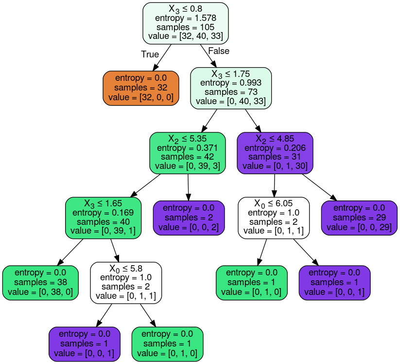

```python
Image(graph.create_png())
```

```python
dtc_model1_score = dtc_model1.score(X_test,y_test)
```

```python
print(dtc_model1_score)
```

```
0.9333333333333333
```

```python
print(metrics.classification_report(y_test, dtc1_predict))
```

```
                 precision    recall  f1-score   support

    Iris-setosa       1.00      1.00      1.00        18
Iris-versicolor       0.77      1.00      0.87        10
 Iris-virginica       1.00      0.82      0.90        17

       accuracy                           0.93        45
      macro avg       0.92      0.94      0.92        45
   weighted avg       0.95      0.93      0.93        45
```

```python
print(metrics.confusion_matrix(y_test, dtc1_predict))
```

```
[[18  0  0]
 [ 0 10  0]
 [ 0  3 14]]
```

```python
# Iris-setosa - 18 - correctly classified - 0 - wrongly classified
# Iris-versicolor - 10 - correctly classified - 0 - wrongly classified
# Iris-virginica - 14 - correctly classified - 3 - wrongly classified
```

```python
# Accuracy
metrics.accuracy_score(y_test, dtc1_predict)
```

```
0.9333333333333333
```

```python
# Cross validation
cross_val_scores3 = cross_val_score(dtc_model1, X_test, y_test, cv = 10)
```

```python
print(cross_val_scores3)
```

```
[0.8 1.  1.  1.  1.  1.  0.8 1.  1.  1. ]
```

```python
cross_val_scores3.mean()
```

```
0.96
```